# Cross-border ANOVA and response structure

Current revised grid · scenarios, regional setups and external closures

## What is compared

The current results tag is **20261002_xi**. Twelve interventions (HH-Food, HH-Energy, HH-Wood, Gov-Plastics, Inv-Metal, Int-Wood, Int-Pulp, Int-Plastics, Int-Metal, Int-Glass, Int-Cement and Int-Energy) are crossed with two regional setups, EU/RoW and North/South, and four external closures: gold, fiat, expenditure-adjusting OPENFIXG and quasi-float. Each intervention is measured against its own arm’s baseline at period 90. Inv-Construction and Int-Construction and the OPENFLEX diagnostic are excluded.

The analysis retains signed responses in both regions across activity, fiscal, external, distributional, financial and ecological outcome blocks. Coordinates are standardized, and the six outcome blocks are weighted equally. A share below is a share of weighted response variation across this declared finite grid, rather than a causal contribution to one trajectory.

## Readable scenario and observation codes

Use **channel–material–closure–setup**: for example, `HH-Food-OPENFIX-gold-NS` or `Int-Metal-OPENFIXG-EU-RoW`. HH means household consumption, Gov government consumption, Inv firm investment, and Int intermediate production. NS is North/South; EU-RoW is EU/rest of world. Gold and fiat remain explicit because OPENFIX alone would be ambiguous. HH and Int are alternative intervention channels; the material name identifies the substitution.

The submitted paper’s material-first abbreviations remain aliases; no simulation IDs or experiments are changed.

| Code | Submitted_alias | In_current_grid |
| --- | --- | --- |
| HH-Food | Food-HH | Yes |
| HH-Energy | Enrg-HH | Yes |
| HH-Wood | Wood-HH | Yes |
| Gov-Plastics | Plst-Gov | Yes |
| Inv-Construction | Cnst-FD | No — construction excluded |
| Inv-Metal | Mtl-FD | Yes |
| Int-Wood | Wood-Int | Yes |
| Int-Pulp | Pulp-Int | Yes |
| Int-Plastics | Plst-Int | Yes |
| Int-Metal | Mtl-Int | Yes |
| Int-Glass | Glss-Int | Yes |
| Int-Cement | Cmnt-Int | Yes |
| Int-Energy | Enrg-Int | Yes |
| Int-Construction | Cnst-Int | No — construction excluded |

## Variables and response units

The pooled analysis studies **37 variables in each region: 74 coordinates**. A scenario profile keeps the eight configurations separately, giving 592 possible coordinates; 578 remain after dropping constant/nonfinite coordinates. Both representations standardize coordinates and give the six outcome blocks equal weight. Correlated and accounting-related coordinates are retained, so these are not 74 independent economic mechanisms.

|  | Block | Variables |
| --- | --- | --- |
| Real activity | Real activity | Total Real Consumption (c); Value Added (va); Gross Output (go); Real Investment in Fixed Capital (id); Nominal Output (y); Final Demand in Real Terms (fd) |
| Fiscal | Fiscal | Government Deficit (gdef); Tax Payments (t); Government Spending (g); Government Debt (b_s); Debt to GDP Ratio (debt_gdp) |
| External | External | Real Final Imports (imp); Real Final Exports (rex); Current Account Balance (cab); Trade Balance (tb) |
| Labour and distribution | Labour and distribution | Employment (n); Female Employment (nf); Profit Share of Disposable Income (shp); Wage Share of Disposable Income (shw); Wage Bill (wb); Disposable Income (yd); Worker Disposable Income (ydw); Capitali… |
| Finance and wealth | Finance and wealth | Household Demand for Personal Loans (lh); Corporate Demand for Bank Loans (lf); Net Household Wealth (v); Fixed Capital Stock (k); Corporate Profit (f_f) |
| Ecological | Ecological | Production of Material Goods (x_mat); Land Used (land); Extraction of Matter (mat); Recycled Matter (rec); Annual CO2 Emissions (emis); Waste (wa); Water Used (water); CO2 Concentration (co2_cum) |

Most measurements are percentage changes from the matching baseline. Current account, trade balance and government deficit are level differences divided by the region’s baseline value added, multiplied by 100. Wage/profit shares and debt/GDP use percentage-point differences; functional inequality uses 100 times its index difference. `co2_cum` is the catalogue’s CO₂-concentration stock measure, distinct from annual emissions. Employment and female employment measure labour demand; wage/profit income shares and class disposable incomes measure functional distribution rather than a household income-distribution Gini.

## Factorial decomposition

For each response coordinate, the complete factorial model separates scenario, setup and closure effects and all their interactions:

$$y_{sac}=\mu+S_s+A_a+C_c+(SA)_{sa}+(SC)_{sc}+(AC)_{ac}+(SAC)_{sac}.$$

The full 12 × 2 × 4 grid has 96 observations and 95 non-intercept degrees of freedom. There are no residual degrees of freedom. These ANOVA sums of squares are descriptive; they do not provide inferential F-tests or p-values.

| term | df | weighted_sum_of_squares | share_percent |
| --- | --- | --- | --- |
| scenario | 11 | 306.254413 | 53.728844 |
| setup | 1 | 6.280370 | 1.101819 |
| closure | 3 | 0.885343 | 0.155323 |
| scenario:setup | 11 | 115.723762 | 20.302414 |
| scenario:closure | 33 | 67.228968 | 11.794556 |
| setup:closure | 3 | 0.813606 | 0.142738 |
| scenario:setup:closure | 33 | 72.813538 | 12.774305 |

Scenario differences account for **53.73%** of weighted variation. Scenario × setup accounts for **20.3%**, scenario × closure for **11.79%**, and the three-way interaction for **12.77%**. Small standalone setup and closure shares do not imply that these dimensions are unimportant: their effects depend substantially on the intervention.

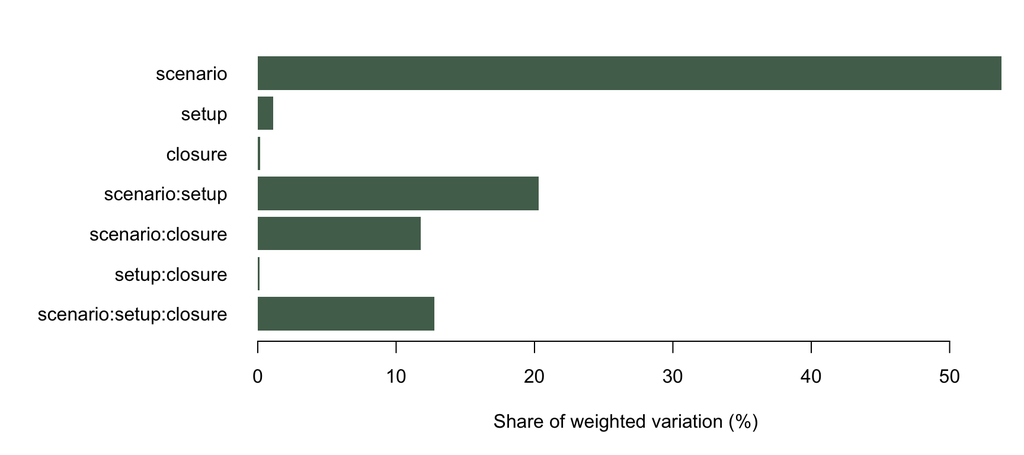

Shares of equally block-weighted standardized response variation in the current finite grid.

## Response grouping and sensitivity

Clustering groups observations by the geometry of their signed response vectors. It does not identify separate economic mechanisms. The selected number of groups changes with the permitted search range and minimum group size:

| cohort | criterion | k | silhouette | singletons | smallest_cluster |
| --- | --- | --- | --- | --- | --- |
| pooled | k 2 to 8 | 7 | 0.483356 | 2 | 1 |
| pooled | k 2 to 20 | 17 | 0.564018 | 3 | 1 |
| pooled | all nonsaturated cuts | 28 | 0.647471 | 9 | 1 |
| pooled | minimum group size 2 | 4 | 0.444614 | 0 | 4 |
| profiles | k 2 to 8 | 2 | 0.387120 | 0 | 2 |
| profiles | k 2 to 20 | 2 | 0.387120 | 0 | 2 |
| profiles | all nonsaturated cuts | 2 | 0.387120 | 0 | 2 |
| profiles | minimum group size 2 | 2 | 0.387120 | 0 | 2 |

The pooled seven-group cut is optimal only over k=2…8. Wider searches or excluding singleton groups select different cuts. Scenario-profile grouping keeps the eight setup/closure configurations in separate coordinates. Search ranges, features, linkage and accounting correlations qualify the interpretation of all groups.

## What the clustering is saying in scenario names

There are two different clustering objects. **Pooled clustering** compares 96 individual scenario × closure × setup observations. Its seven-group cut contains a large mixed group of 65 observations and an energy/metal-related group of 20, then smaller regional/closure-specific groups. It is not seven clean policy categories.

| Group | Observations | Scenario_codes | Configurations |
| --- | --- | --- | --- |
| 1 | 65 | HH-Food, HH-Wood, Gov-Plastics, Inv-Metal, Int-Wood, Int-Pulp, Int-Plastics, Int-Glass, Int-Cement | Mixed responses across setups and closures; inspect the membership table below |
| 2 | 20 | HH-Energy, Int-Metal, Int-Energy | HH-Energy and Int-Energy in all eight arms; Int-Metal in the four EU/RoW arms |
| 3 | 3 | HH-Food | HH-Food-OPENFIX-gold-NS; HH-Food-OPENFIX-fiat-NS; HH-Food-Quasifloat-NS |
| 4 | 3 | Int-Metal | Int-Metal-OPENFIX-gold-NS; Int-Metal-OPENFIX-fiat-NS; Int-Metal-Quasifloat-NS |
| 5 | 1 | HH-Food | HH-Food-OPENFIXG-NS |
| 6 | 1 | Int-Metal | Int-Metal-OPENFIXG-NS |
| 7 | 3 | HH-Food, Gov-Plastics, Int-Plastics | HH-Food-OPENFIXG-EU-RoW; Gov-Plastics-OPENFIXG-EU-RoW; Int-Plastics-OPENFIXG-EU-RoW |

**Scenario-profile clustering** compares twelve entire interventions, preserving all eight configurations in separate coordinates. Its selected two-group split places **Int-Metal and Int-Energy together**, with HH-Food, HH-Energy, HH-Wood, Gov-Plastics, Inv-Metal, Int-Wood, Int-Pulp, Int-Plastics, Int-Glass and Int-Cement in the other group. This says those two interventions have a distinctive joint response profile under this metric. Linkage changes and feature-selection sensitivity qualify that split; it is not a universal two-regime result.

## Hierarchical clustering: named branches and regime fingerprints

Tree Groups 2Highlight

Branch geometry uses Ward D2 on all retained standardized, equally block-weighted coordinates. Coloured circles identify statistical groups at the chosen cut. Regime tiles use the separate value-added rule; hover or focus them for signed responses. Regime colours follow the tree’s first split: warm colours (FIC, CD) are the EU-gains/RoW-loses regimes, cool colours (PL, then the two SC branches) the rest. In the 96-observation tree the first branch holds every configuration of Sc2 HH-Energy, Sc10 Int-Metal and Sc13 Int-Energy; in the 12-profile tree it holds Sc10 Int-Metal and Sc13 Int-Energy, and Sc2 HH-Energy joins the other branch. Built on one regional setup at a time, the trees differ: on EU/RoW alone the first branch is exactly Sc2 HH-Energy, Sc10 Int-Metal and Sc13 Int-Energy, the three FIC/CD scenarios; on North/South alone Sc1 HH-Food splits off first.

Select a named leaf or regime tile to inspect it. Highlighting preserves the full hierarchy.

**Why Int-Metal is active while Inv-Metal is nearly inert.** Int-Metal (`Mtl-Int`) changes intermediate input composition. Inv-Metal (`Mtl-FD`) changes firms’ investment composition. Under revised investment equation R9, that composition weights net investment; replacement purchases follow the capital matrix. Near a stationary baseline net investment is almost zero, so Inv-Metal’s revised response is tiny. This does not establish that substituting replacement-capital purchases would be ineffective. The intervention has not been redefined here.

## PCA: the main response directions

Principal component analysis (PCA) finds orthogonal directions capturing the most variation in the same standardized, equally block-weighted response space. It is a projection of response geometry, not an identified causal decomposition. Cluster colours below use the selected Ward cut; changing the cut does not change the PCA axes.

|  | Representation | Component | Variance (%) | Cumulative (%) |
| --- | --- | --- | --- | --- |
| 1 | pooled | 1 | 39.663 | 39.663 |
| 2 | pooled | 2 | 24.762 | 64.425 |
| 3 | pooled | 3 | 12.427 | 76.851 |
| 75 | profiles | 1 | 55.852 | 55.852 |
| 76 | profiles | 2 | 21.890 | 77.742 |
| 77 | profiles | 3 | 10.945 | 88.687 |

For pooled observations, PC1 and PC2 together capture **64.42%** and the first three capture **76.85%**. For scenario profiles, the first two capture **77.74%**. A two-dimensional plot therefore omits part of the distance used for clustering.

Representation Cluster cut Outlined Ward ovals Shaded regime ovalsFind

Hover or focus a point for its scenario, closure, setup, cluster and transmission branch.

[output not shown]

### Which variables define the axes?

The largest absolute pooled loadings on PC1 concern region-1 real exports, region-2 real imports and region-2 loans, wealth, tax and corporate profits. PC2 emphasizes region-1 wealth, tax, value added, profits, corporate loans and imports. PC3 emphasizes public debt/deficit and trade-balance contrasts. These are statistical associations in weighted coordinates. Z1/Z2 are regional roles: EU/RoW in one setup, North/South in the other. The sign of a PCA axis is arbitrary.

|  | component | zone | name | variable | block | loading |
| --- | --- | --- | --- | --- | --- | --- |
| 23 | 1 | Z1 | Real Final Exports | rex | External | -0.21012 |
| 50 | 1 | Z2 | Real Final Imports | imp | External | -0.21012 |
| 54 | 1 | Z2 | Corporate Demand for Bank Loans | lf | Finance and wealth | -0.19991 |
| 65 | 1 | Z2 | Net Household Wealth | v | Finance and wealth | -0.19871 |
| 63 | 1 | Z2 | Tax Payments | t | Fiscal | -0.19834 |
| 44 | 1 | Z2 | Corporate Profit | f_f | Finance and wealth | -0.19739 |
| 102 | 2 | Z1 | Net Household Wealth | v | Finance and wealth | 0.24100 |
| 100 | 2 | Z1 | Tax Payments | t | Fiscal | 0.23984 |
| 103 | 2 | Z1 | Value Added | va | Real activity | 0.22965 |
| 81 | 2 | Z1 | Corporate Profit | f_f | Finance and wealth | 0.22941 |
| 91 | 2 | Z1 | Corporate Demand for Bank Loans | lf | Finance and wealth | 0.22748 |
| 87 | 2 | Z1 | Real Final Imports | imp | External | 0.22310 |
| 149 | 3 | Z1 | Government Debt | b_s | Fiscal | 0.24957 |
| 158 | 3 | Z1 | Government Deficit | gdef | Fiscal | 0.24738 |
| 190 | 3 | Z2 | Debt to GDP Ratio | debt_gdp | Fiscal | -0.24571 |
| 186 | 3 | Z2 | Government Debt | b_s | Fiscal | -0.24297 |
| 175 | 3 | Z1 | Trade Balance | tb | External | -0.23510 |
| 212 | 3 | Z2 | Trade Balance | tb | External | 0.23148 |

## Two SC branches, not two independently discovered clusters

The fitted sign/threshold rule has two SC branches:

- **SC-weak — 47 observations:** |region-2 VA response| < 0.003%. This branch is evaluated first; it does not require both regions’ VA changes to be negative. “Symmetric contraction” is the inherited label for this near-zero spillover branch.
- **SC-both — 19 observations:** both regions’ VA responses are negative after the weak-response branch has been excluded.

| Rule branch | Observations |
| --- | --- |
| CD: Z1 expands, Z2 contracts | 3 |
| FIC: energy, Z1 expands, Z2 contracts | 14 |
| PL: Z1 contracts, Z2 expands | 12 |
| SC: both regions contract | 19 |
| SC: weak Z2 response | 47 |
| UN: both regions expand | 1 |

## Closure-by-scenario regime map

SCw means weak region-2 VA response; SCc means both regions contract beyond the weak-response branch. PL = production leakage, FIC = fossil import collapse, CD = competitive displacement, UN = both regions expand outside the submitted four-label taxonomy. The heatmap distinguishes the two SC branches; each tile is a separate baseline-matched experiment.

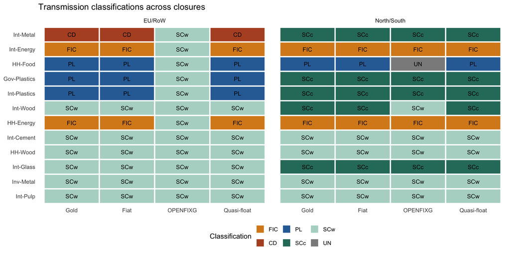

Current period-90 classification by named intervention, closure and regional setup. Rows follow the leaf order of the twelve-profile Ward tree. The inherited FIC label is a fitted classification convention, not independent evidence of an energy-trade mechanism.

Gold, fiat and quasi-float give the same broad classification for every included scenario within each setup. OPENFIXG changes six of twelve EU/RoW classifications and one of twelve North/South classifications relative to gold. It also changes North/South Int-Wood from SCc to SCw, without changing its broad SC label. Identical classifications can still conceal different response magnitudes.

**Where fossil import collapse appears:** HH-Energy and Int-Energy are FIC under gold, fiat and quasi-float in both setups and under North/South OPENFIXG: fourteen observations. EU/RoW OPENFIXG yields positive Z1 responses and positive but sub-threshold Z2 responses, classified SCw. Thus these exceptions do not mean both regions contract. FIC and EU/RoW Int-Metal’s CD can be close in response-space clustering despite carrying different taxonomy labels.

## What changes from the submitted paper?

There are two comparisons. Holding EU/RoW and gold closure as the reference configuration, **all twelve retained broad classifications agree with the submitted paper**. Extending the revised model to both setups and all four closures produces **19 of 96 observations that differ from their scenario’s submitted reference label**. This is a comparison with a fixed submitted label, not 96 matched old-model reruns. The construction interventions are excluded.

The unchanged reference classifications do not imply unchanged magnitudes. The following table compares archived submitted and current revised EU/RoW gold VA responses directly. Signs can change inside SC because SCw is a near-zero-spillover category.

| Scenario | Submitted label | Current label | EU submitted (%) | EU current (%) | RoW submitted (%) | RoW current (%) |
| --- | --- | --- | --- | --- | --- | --- |
| HH-Food | PL | PL | -0.021407 | -0.032146 | 0.005630 | 0.014512 |
| HH-Energy | FIC | FIC | 0.026468 | 0.043626 | -0.009005 | -0.005312 |
| HH-Wood | SC | SC | -0.000451 | 0.001555 | 0.000040 | -0.000319 |
| Gov-Plastics | PL | PL | -0.020840 | -0.007455 | 0.005962 | 0.009582 |
| Inv-Metal | SC | SC | 0.001366 | 0.000000 | -0.000430 | 0.000006 |
| Int-Wood | SC | SC | 0.001018 | -0.034648 | 0.000338 | -0.002459 |
| Int-Pulp | SC | SC | -0.000803 | -0.003545 | 0.000199 | -0.000050 |
| Int-Plastics | PL | PL | -0.015025 | -0.012998 | 0.004988 | 0.009817 |
| Int-Metal | CD | CD | 0.050100 | 0.032864 | -0.012405 | -0.014390 |
| Int-Glass | SC | SC | 0.003727 | -0.001285 | -0.001032 | -0.001593 |
| Int-Cement | SC | SC | 0.002149 | -0.000132 | 0.000218 | 0.000577 |
| Int-Energy | FIC | FIC | 0.044820 | 0.093002 | -0.016818 | -0.006539 |

The submitted dendrogram used scaled EU−RoW divergence profiles for one model/configuration. The current profile tree uses joint regional responses across eight configurations with equal outcome-block weighting. Their branches are not directly comparable measures of model change: both the model and the clustering representation differ. The retained original submitted dendrogram is available in Analysis’s submitted ANOVA pages.

## Signed transmission labels

The period-90 classification applies the fixed threshold τ=0.003% of region-2 baseline value added. SC includes both the weak-region-2 response and both-contracting branches; the other labels are production leakage (PL), fossil import collapse (FIC), competitive displacement (CD) and unclassified (UN).

| Label | Observations |
| --- | --- |
| CD | 3 |
| FIC | 14 |
| PL | 12 |
| SC | 66 |
| UN | 1 |

All 96 labels remain unchanged by the Ξ-consistent recalibration. Numerical magnitudes and their decomposition have been regenerated. The quasi-float EU baseline retains the documented debt-slope exception, so acceptance of these observations is not a strict-stationarity or attraction claim.

## Sources and related analyses

Current tables are read from `transmission_structure_<tag>/` and `transmission_regime_grid_<tag>/`, selected by `data/current_results.json`. The calculations are implemented in `R/scenarios/transmission_cluster_structure.R` and `R/scenarios/classify_transmission_grid.R`.

The Analysis section also retains the submitted-scenario cross-border ANOVA, its construction-excluded variant, and the dated pre-recalibration revised-grid analysis. Those are separate experiments. Documentation contains the calibration comparison and diagnostic reports; Discussion explains what the current evidence supports and what remains an author decision.